# Relationship between transmission type and car performance in miles per gallon (MPG)

Nathalie Descusse-Brown

March 6, 2019

## Overview

US automobile magazine Motor Trend has decided to look at the relationshop between car performance measured in miles per gallon (mpg) and the tranmission type for data extracted from the 1974 edition of the magazine. In particular, this paper seeks to address the following questions: 1. Is an automatic or manual transmission better for MPG? 2. What is the MPG difference between automatic and manual transmissions?

The data used for this analysis comprises fuel consumption and 10 aspects of automobile design and performance for 32 automobiles (1973-1974 models).

## Data Processing and Exploratory Analysis

```r
library(datasets)
data(mtcars)
mpg <- mtcars$mpg

for (i in 1:dim(mtcars)[1]) {
        if (mtcars$am[i]==1) {
                mtcars$trans[i] <- "manual"
        }
        else mtcars$trans[i] <- "automatic"
}


head(mtcars)
```

```
##                    mpg cyl disp  hp drat    wt  qsec vs am gear carb
## Mazda RX4         21.0   6  160 110 3.90 2.620 16.46  0  1    4    4
## Mazda RX4 Wag     21.0   6  160 110 3.90 2.875 17.02  0  1    4    4
## Datsun 710        22.8   4  108  93 3.85 2.320 18.61  1  1    4    1
## Hornet 4 Drive    21.4   6  258 110 3.08 3.215 19.44  1  0    3    1
## Hornet Sportabout 18.7   8  360 175 3.15 3.440 17.02  0  0    3    2
## Valiant           18.1   6  225 105 2.76 3.460 20.22  1  0    3    1
##                       trans
## Mazda RX4            manual
## Mazda RX4 Wag        manual
## Datsun 710           manual
## Hornet 4 Drive    automatic
## Hornet Sportabout automatic
## Valiant           automatic
```

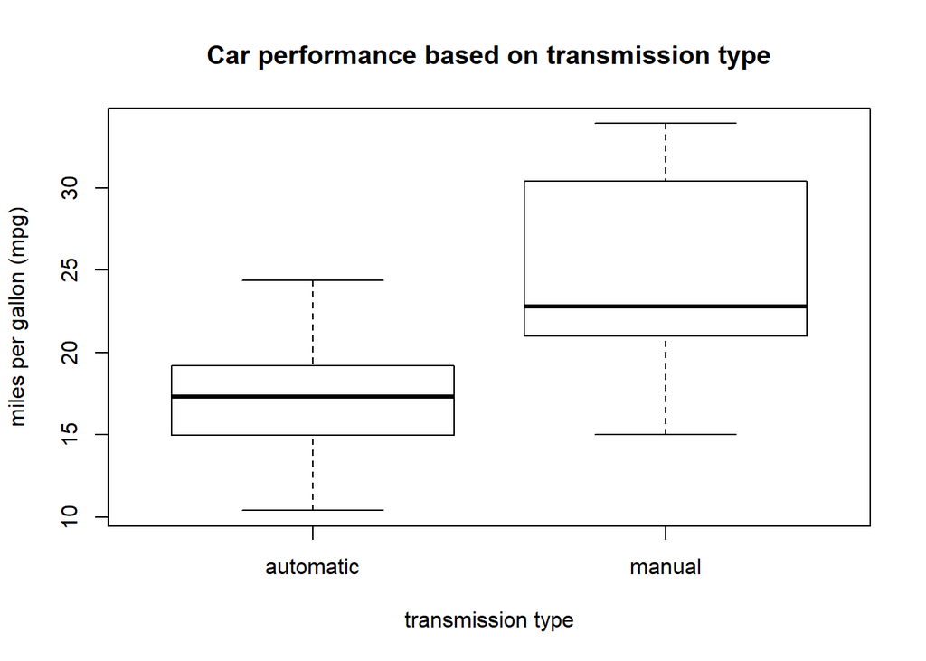

```r
boxplot(mpg ~ trans, data=mtcars, xlab="transmission type",ylab="miles per gallon (mpg)",main="Car performance based on transmission type")
```

We also wanted to have a quick look at the correlation between the various parameters in the dataset, as seen in the plot below.

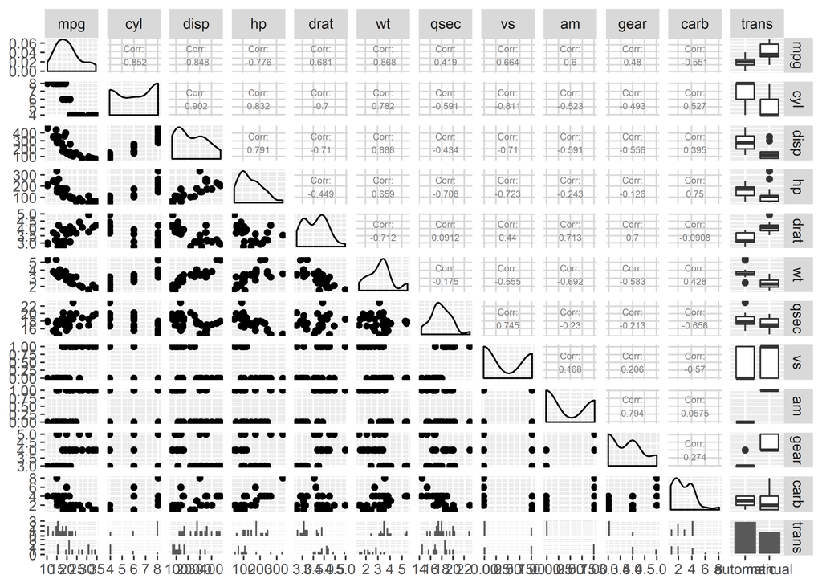

```r
library(ggplot2)
library(GGally)
ggpairs(mtcars,lower=list(continuous=wrap(ggally_points)),  upper=list(continuous = wrap("cor", size = 2, alignPercent = 1)))
```

Some more exploratory plot exploring the relationship between mpg, transmission type and number of cylinders further:

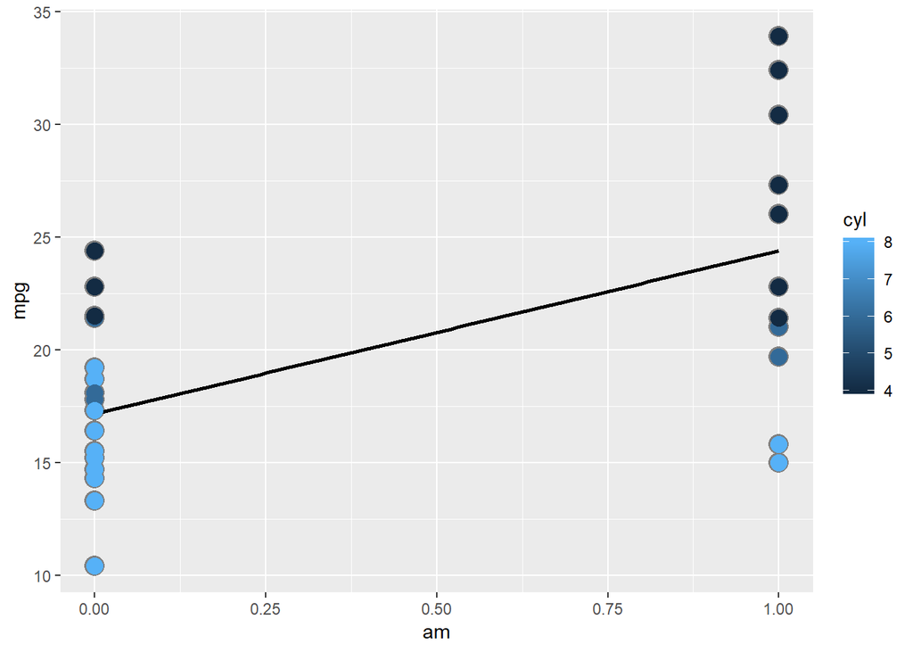

```r
library(ggplot2)
g = ggplot(mtcars,aes(y=mpg,x=am,colour=cyl))
g = g + geom_point(colour="grey50",size=5)+geom_smooth(method=lm,se=FALSE,colour="black")+geom_point(size=4)
g
```

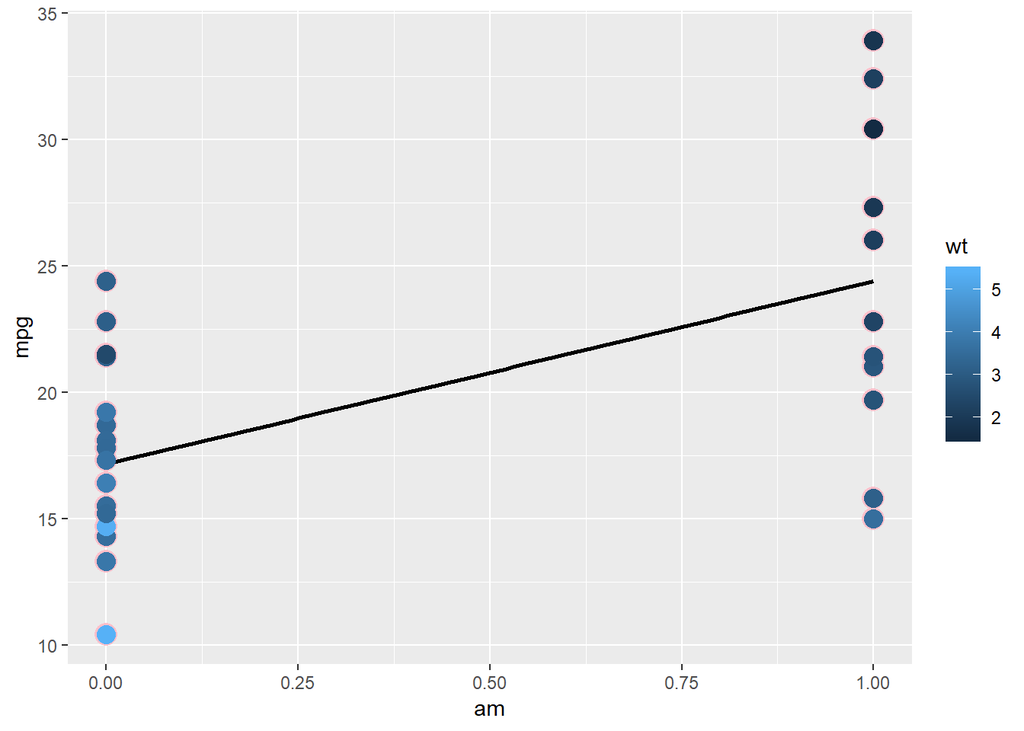

```r
g2 = ggplot(mtcars,aes(y=mpg,x=am,colour=wt))
g2 = g2 + geom_point(colour="pink",size=5)+geom_smooth(method=lm,se=FALSE,colour="black")+geom_point(size=4)
g2
```

## Model selection and results

```r
library(MASS)
library(car)
lmregression <- lm(mpg ~ I(factor(am)) + wt + I(factor(cyl)) + hp,data=mtcars)

summary(lmregression)
```

```
##
## Call:
## lm(formula = mpg ~ I(factor(am)) + wt + I(factor(cyl)) + hp,
##     data = mtcars)
##
## Residuals:
##     Min      1Q  Median      3Q     Max
## -3.9387 -1.2560 -0.4013  1.1253  5.0513
##
## Coefficients:
##                 Estimate Std. Error t value Pr(>|t|)
## (Intercept)     33.70832    2.60489  12.940 7.73e-13 ***
## I(factor(am))1   1.80921    1.39630   1.296  0.20646
## wt              -2.49683    0.88559  -2.819  0.00908 **
## I(factor(cyl))6 -3.03134    1.40728  -2.154  0.04068 *
## I(factor(cyl))8 -2.16368    2.28425  -0.947  0.35225
## hp              -0.03211    0.01369  -2.345  0.02693 *
## ---
## Signif. codes:  0 '***' 0.001 '**' 0.01 '*' 0.05 '.' 0.1 ' ' 1
##
## Residual standard error: 2.41 on 26 degrees of freedom
## Multiple R-squared:  0.8659, Adjusted R-squared:  0.8401
## F-statistic: 33.57 on 5 and 26 DF,  p-value: 1.506e-10
```

### Check of assumptions made in linear regression model

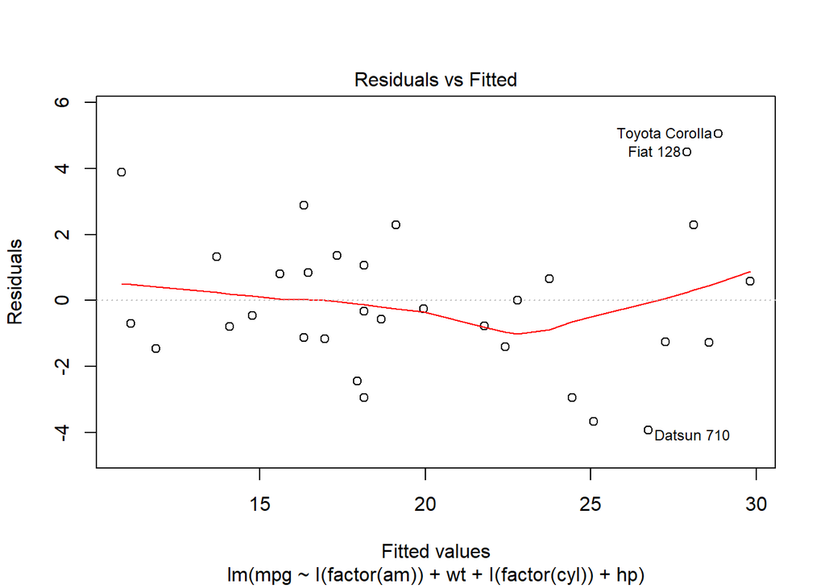

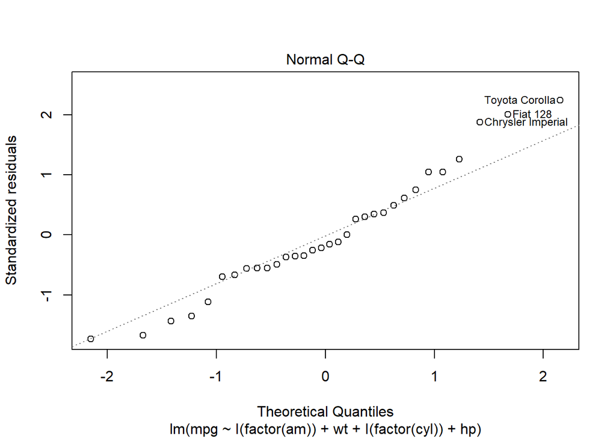

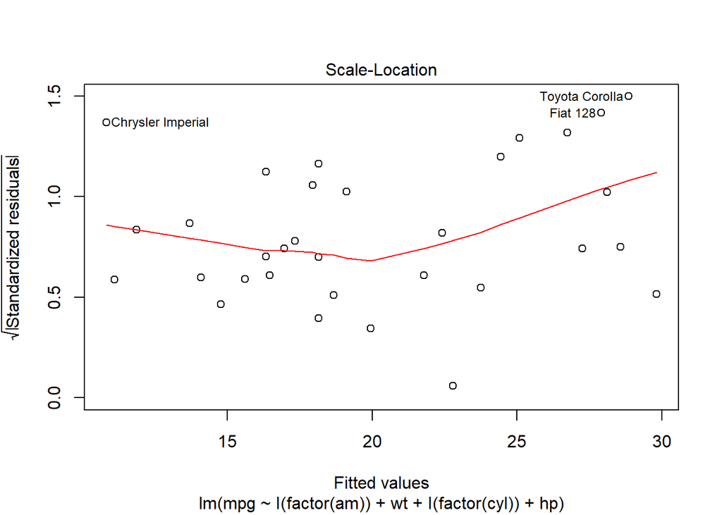

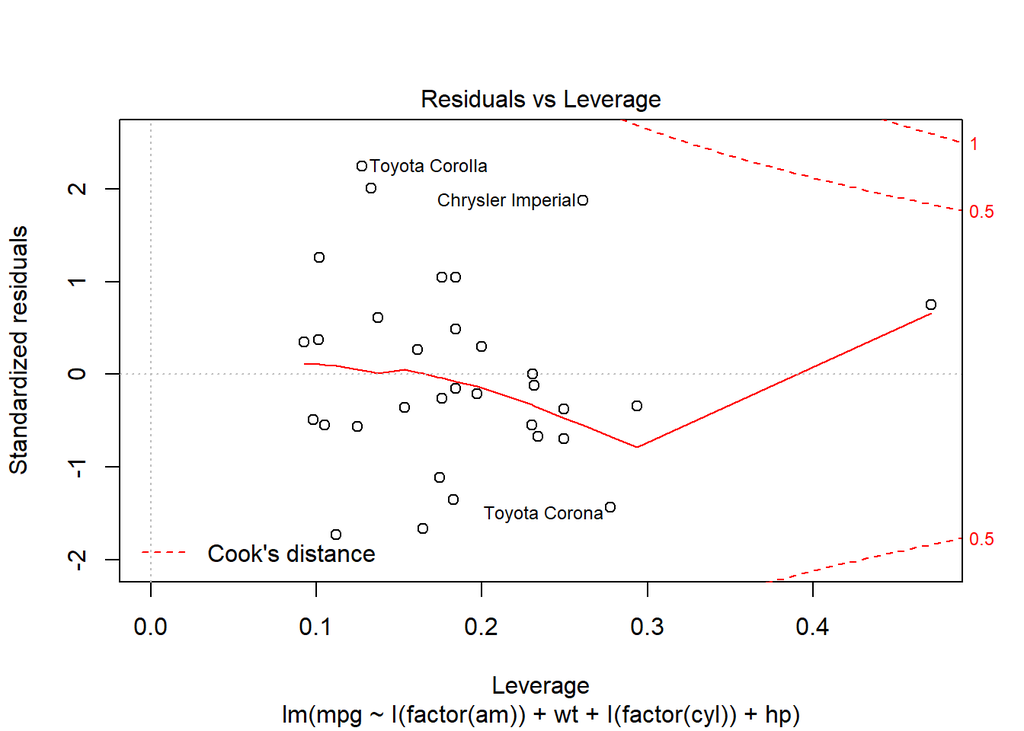

```r
plot(lmregression)
```

### Permutations to increase sample size

We made the assumption of a normal distribution for the 2 selected subsets, automatic transmission and manual transmission. However because the number of samples is small, we used permutations to generate more samples.

```r
group <- as.character(mtcars$trans)
testStat <- function(v,g) mean(v[g == "manual"]) - mean(v[g == "automatic"])
observedStat <- testStat(mtcars$mpg,group)
permutations <- sapply(1:100000,function(i) testStat(mtcars$mpg,sample(group)))
prob <- mean(permutations>observedStat)

head(permutations, 20)
```

```
##  [1]  2.8012146 -0.8133603 -2.0441296  0.5728745 -1.4222672 -5.9696356
##  [7] -1.7461538  1.5056680 -0.9688259 -1.7979757 -2.3809717 -2.0441296
## [13]  1.5186235 -0.3210526 -0.1655870  1.2854251 -1.0983806 -0.1008097
## [19]  1.2724696 -3.8838057
```

```r
prob
```

```
## [1] 0.00027
```

```r
observedStat
```

```
## [1] 7.244939
```

## Discussion

The plot of the residuals doesn’t seem to have any pattern to it although some of the outliers appear to exert significant leverage.

```r
hatvalues(lmregression)
```

```
##           Mazda RX4       Mazda RX4 Wag          Datsun 710
##          0.23394025          0.24961103          0.11198028
##      Hornet 4 Drive   Hornet Sportabout             Valiant
##          0.18403386          0.13716428          0.17576630
##          Duster 360           Merc 240D            Merc 230
##          0.19727048          0.19997207          0.23053840
##            Merc 280           Merc 280C          Merc 450SE
##          0.18416901          0.18416901          0.09272718
##          Merc 450SL         Merc 450SLC  Cadillac Fleetwood
##          0.10113822          0.09794356          0.24960265
## Lincoln Continental   Chrysler Imperial            Fiat 128
##          0.29368193          0.26111685          0.13312367
##         Honda Civic      Toyota Corolla       Toyota Corona
##          0.16134813          0.12773093          0.27778717
##    Dodge Challenger         AMC Javelin          Camaro Z28
##          0.17439185          0.18284566          0.15334218
##    Pontiac Firebird           Fiat X1-9       Porsche 914-2
##          0.10164174          0.12459631          0.10489565
##        Lotus Europa      Ford Pantera L        Ferrari Dino
##          0.17589121          0.23019046          0.23157220
##       Maserati Bora          Volvo 142E
##          0.47136712          0.16445037
```

## Appendix A: Investigation of effect of inclusion of given covariable for model fitting

```r
library(MASS)
library(car)
lmregression1 <- lm(mpg ~ I(factor(am)),data=mtcars)
lmregression11 <- lm(mpg ~ I(factor(am)) + wt,data=mtcars)

lmregression21 <- lm(mpg ~ I(factor(am)) + wt + I(factor(cyl)), data=mtcars)
lmregression22 <- lm(mpg ~ I(factor(am)) + wt + hp,data=mtcars)
lmregression23 <- lm(mpg ~ I(factor(am)) + wt + disp,data=mtcars)
lmregression24 <- lm(mpg ~ I(factor(am)) + wt + drat,data=mtcars)
lmregression25 <- lm(mpg ~ I(factor(am)) + wt + qsec,data=mtcars)
lmregression26 <- lm(mpg ~ I(factor(am)) + wt + I(factor(vs)),data=mtcars)
lmregression27 <- lm(mpg ~ I(factor(am)) + wt + I(factor(gear)),data=mtcars)
lmregression28 <- lm(mpg ~ I(factor(am)) + wt + I(factor(carb)),data=mtcars)
#lmregressionn <- lm(mpg ~ I(factor(am)) + I(factor(cyl)) + hp + disp + drat + wt + qsec + I(factor(vs)) + I(factor(gear)) + I(factor(carb)),data=mtcars)


anova(lmregression11,lmregression21)
```

```
## Analysis of Variance Table
##
## Model 1: mpg ~ I(factor(am)) + wt
## Model 2: mpg ~ I(factor(am)) + wt + I(factor(cyl))
##   Res.Df    RSS Df Sum of Sq      F   Pr(>F)
## 1     29 278.32
## 2     27 182.97  2    95.351 7.0353 0.003473 **
## ---
## Signif. codes:  0 '***' 0.001 '**' 0.01 '*' 0.05 '.' 0.1 ' ' 1
```

```r
anova(lmregression11,lmregression22)
```

```
## Analysis of Variance Table
##
## Model 1: mpg ~ I(factor(am)) + wt
## Model 2: mpg ~ I(factor(am)) + wt + hp
##   Res.Df    RSS Df Sum of Sq      F    Pr(>F)
## 1     29 278.32
## 2     28 180.29  1    98.029 15.224 0.0005464 ***
## ---
## Signif. codes:  0 '***' 0.001 '**' 0.01 '*' 0.05 '.' 0.1 ' ' 1
```

```r
anova(lmregression11,lmregression23)
```

```
## Analysis of Variance Table
##
## Model 1: mpg ~ I(factor(am)) + wt
## Model 2: mpg ~ I(factor(am)) + wt + disp
##   Res.Df    RSS Df Sum of Sq      F  Pr(>F)
## 1     29 278.32
## 2     28 246.56  1    31.763 3.6072 0.06788 .
## ---
## Signif. codes:  0 '***' 0.001 '**' 0.01 '*' 0.05 '.' 0.1 ' ' 1
```

```r
anova(lmregression11,lmregression24)
```

```
## Analysis of Variance Table
##
## Model 1: mpg ~ I(factor(am)) + wt
## Model 2: mpg ~ I(factor(am)) + wt + drat
##   Res.Df    RSS Df Sum of Sq      F Pr(>F)
## 1     29 278.32
## 2     28 266.99  1    11.332 1.1884 0.2849
```

```r
anova(lmregression11,lmregression25)
```

```
## Analysis of Variance Table
##
## Model 1: mpg ~ I(factor(am)) + wt
## Model 2: mpg ~ I(factor(am)) + wt + qsec
##   Res.Df    RSS Df Sum of Sq      F    Pr(>F)
## 1     29 278.32
## 2     28 169.29  1    109.03 18.034 0.0002162 ***
## ---
## Signif. codes:  0 '***' 0.001 '**' 0.01 '*' 0.05 '.' 0.1 ' ' 1
```

```r
anova(lmregression11,lmregression26)
```

```
## Analysis of Variance Table
##
## Model 1: mpg ~ I(factor(am)) + wt
## Model 2: mpg ~ I(factor(am)) + wt + I(factor(vs))
##   Res.Df    RSS Df Sum of Sq      F   Pr(>F)
## 1     29 278.32
## 2     28 216.32  1    62.004 8.0258 0.008454 **
## ---
## Signif. codes:  0 '***' 0.001 '**' 0.01 '*' 0.05 '.' 0.1 ' ' 1
```

```r
anova(lmregression11,lmregression27)
```

```
## Analysis of Variance Table
##
## Model 1: mpg ~ I(factor(am)) + wt
## Model 2: mpg ~ I(factor(am)) + wt + I(factor(gear))
##   Res.Df    RSS Df Sum of Sq      F Pr(>F)
## 1     29 278.32
## 2     27 237.87  2    40.448 2.2955   0.12
```

```r
anova(lmregression11,lmregression28)
```

```
## Analysis of Variance Table
##
## Model 1: mpg ~ I(factor(am)) + wt
## Model 2: mpg ~ I(factor(am)) + wt + I(factor(carb))
##   Res.Df    RSS Df Sum of Sq      F Pr(>F)
## 1     29 278.32
## 2     24 214.19  5    64.133 1.4373 0.2471
```

```r
lmregression31 <- lm(mpg ~ I(factor(am)) + wt + I(factor(cyl)) + hp, data=mtcars)
lmregression32 <- lm(mpg ~ I(factor(am)) + wt + I(factor(cyl)) + qsec, data=mtcars)
lmregression33 <- lm(mpg ~ I(factor(am)) + wt + I(factor(cyl)) + I(factor(vs)), data=mtcars)

anova(lmregression21,lmregression31)
```

```
## Analysis of Variance Table
##
## Model 1: mpg ~ I(factor(am)) + wt + I(factor(cyl))
## Model 2: mpg ~ I(factor(am)) + wt + I(factor(cyl)) + hp
##   Res.Df    RSS Df Sum of Sq      F  Pr(>F)
## 1     27 182.97
## 2     26 151.03  1    31.943 5.4991 0.02693 *
## ---
## Signif. codes:  0 '***' 0.001 '**' 0.01 '*' 0.05 '.' 0.1 ' ' 1
```

```r
anova(lmregression21,lmregression32)
```

```
## Analysis of Variance Table
##
## Model 1: mpg ~ I(factor(am)) + wt + I(factor(cyl))
## Model 2: mpg ~ I(factor(am)) + wt + I(factor(cyl)) + qsec
##   Res.Df    RSS Df Sum of Sq      F  Pr(>F)
## 1     27 182.97
## 2     26 159.42  1    23.544 3.8397 0.06086 .
## ---
## Signif. codes:  0 '***' 0.001 '**' 0.01 '*' 0.05 '.' 0.1 ' ' 1
```

```r
anova(lmregression21,lmregression33)
```

```
## Analysis of Variance Table
##
## Model 1: mpg ~ I(factor(am)) + wt + I(factor(cyl))
## Model 2: mpg ~ I(factor(am)) + wt + I(factor(cyl)) + I(factor(vs))
##   Res.Df    RSS Df Sum of Sq      F Pr(>F)
## 1     27 182.97
## 2     26 180.02  1    2.9446 0.4253   0.52
```